# Trzecie starcie - wizualizacje

7 października 2017

## Ładowanie pakietów

```r
library(dplyr)
library(tidyr)
library(ggplot2)
library(ggthemes)
knitr::opts_chunk$set(fig.height = 3)
```

## Przygotowanie danych

```r
mieszkania <- read.csv(file = "data/mieszkania_wroclaw_ceny.csv") %>%
  mutate(duze = metraz > 50,
         pietro = ifelse(pietro == 0, "parter",
                         ifelse(pietro == pietro_maks, "ostatnie_pietro",
                                ifelse(pietro > 15, "wysoko",
                                       ifelse(pietro_maks < 3, "niska_zabudowa", "inne")))),
         pietro = factor(pietro),
         pokoj = factor(ifelse(n_pokoj > 3, ">3", n_pokoj)))
```

## Idea ggplot

- Podajemy jakie zmienne powinny się znaleźć na obu osiach
- Wybieramy jakiego rodzaju wykres chcemy (punkty, słupki itp)
- https://github.com/rstudio/cheatsheets/raw/master/data-visualization-2.1.pdf

## Wykres słupkowy

## Przypomnienie

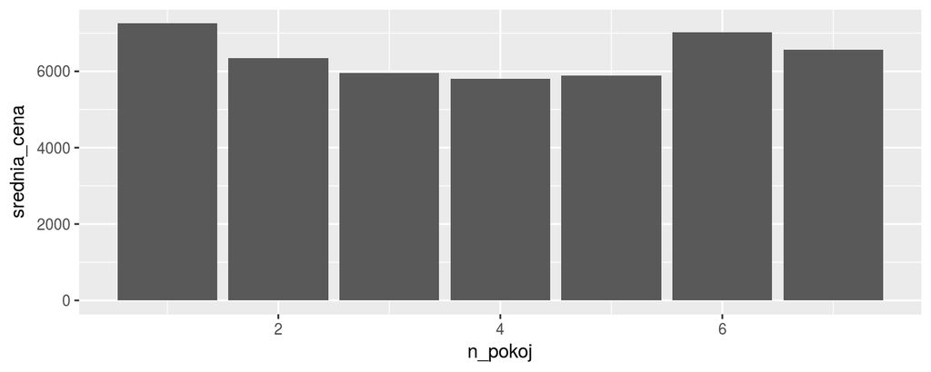

```r
srednia_cena_pokoje <- mieszkania %>%
  group_by(n_pokoj) %>% summarise(srednia_cena = mean(cena_m2))
ggplot(srednia_cena_pokoje, aes(x = n_pokoj, y = srednia_cena)) +
  geom_bar(stat = "identity")
```

- Jeśli pominiemy paramter *stat=identity* to R zliczby wystąpienia

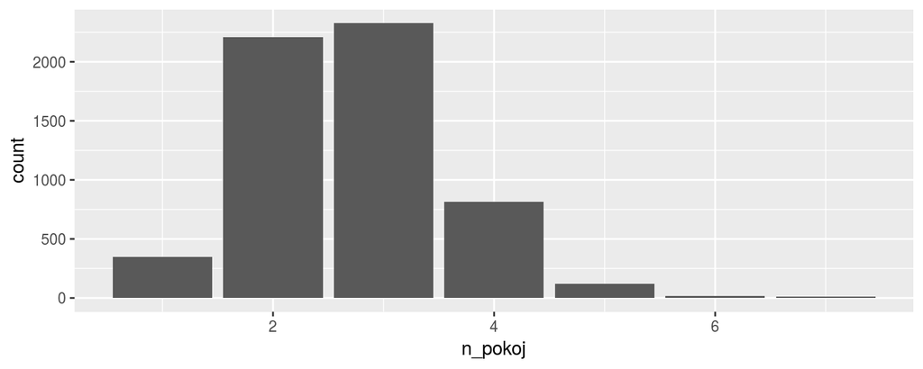

```r
ggplot(mieszkania, aes(x = n_pokoj)) +
  geom_bar()
```

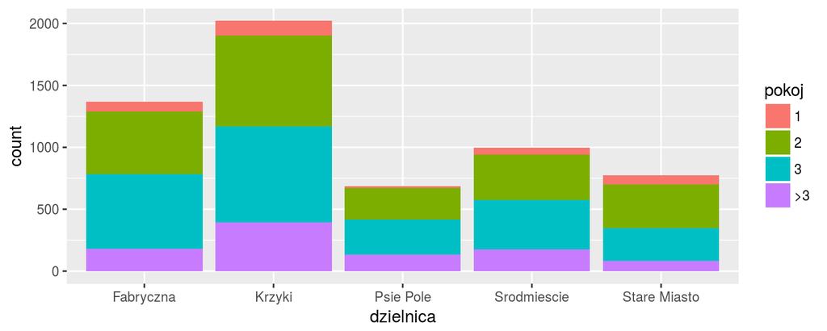

```r
ggplot(mieszkania, aes(x = dzielnica, y = ..count.., fill = pokoj)) +
  geom_bar(position = "stack")
```

- Aby móc łatwo porównać skalujemy każdy słupek do tej samej wysokości
- Gdzie mamy największe, a gdzie najmniejsze mieszkania?

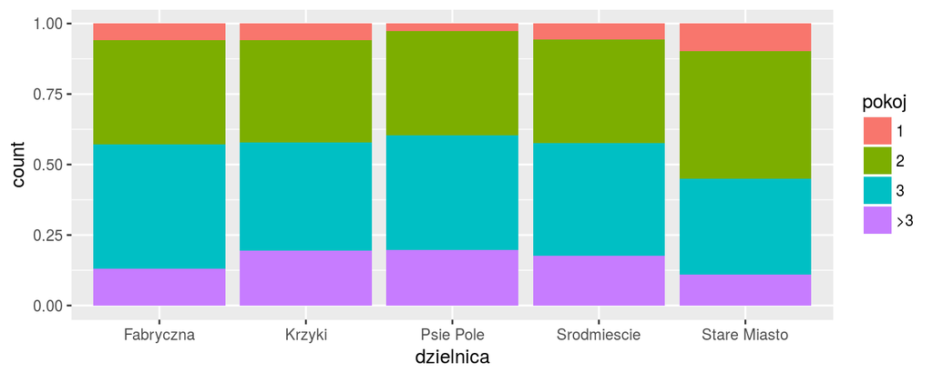

```r
ggplot(mieszkania, aes(x = dzielnica, fill = pokoj)) +
  geom_bar(position = "fill")
```

- Wykres słupkowy można uzupełnić dokładnymi wysokościami słupków wykorzystując funkcje ggplot2.

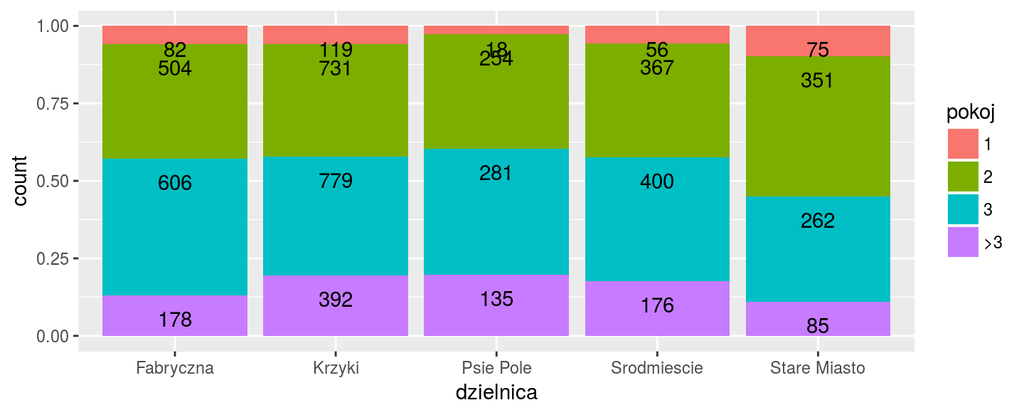

```r
ggplot(mieszkania, aes(x = dzielnica, fill = pokoj,
                       label = ..count..)) +
  geom_bar(position = "fill") +
  geom_text(stat = "count", position = "fill", vjust = 2)
```

## Zadania

1. Stwórz wykres słupkowy pokazujący jak średni metraż zależy od liczby pokojów
2. Dodaj wypełnienie (*fill*) kolorem zależnym od zmiennej *n_pokoj*
3. Stwórz wykres pokazujący ile jest ofert w zależności od dzielnicy
4. Dodaj wypełnienie zależne od zmiennej *pokoj*
5. Dodaj liczbę ofert przy pomocy geom_text.

## Słupki błędów

Najpierw policzmy średnie i odchylenia standardowe:

```r
dat_srednia <- group_by(mieszkania, pietro, dzielnica, duze) %>%
  summarise(mean_cena = mean(cena_m2),
            sd_cena = sd(cena_m2))
head(dat_srednia)
```

```
## # A tibble: 6 x 5
## # Groups:   pietro, dzielnica [3]
##   pietro dzielnica  duze mean_cena   sd_cena
##   <fctr>    <fctr> <lgl>     <dbl>     <dbl>
## 1   inne Fabryczna FALSE  6207.463  881.0245
## 2   inne Fabryczna  TRUE  5618.244  988.2345
## 3   inne    Krzyki FALSE  6641.454 1087.2795
## 4   inne    Krzyki  TRUE  5988.199 1375.3610
## 5   inne Psie Pole FALSE  5869.464  914.0959
## 6   inne Psie Pole  TRUE  5473.645  875.2137
```

Tym razem wykorzystujemy *stat = "identity"*, aby okreslić wysokość słupków.

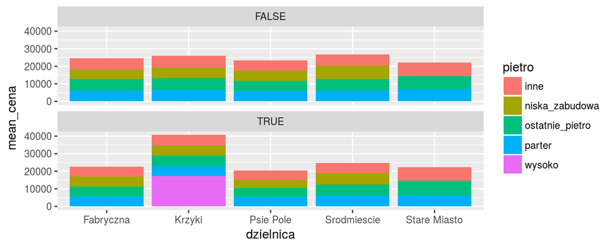

```r
ggplot(dat_srednia, aes(x = dzielnica, y = mean_cena, fill = pietro)) +
  geom_bar(stat = "identity") +
  facet_wrap(~ duze, ncol = 1)
```

Zmieniamy na *position = "dodge"*, aby słupki stały obok siebie.

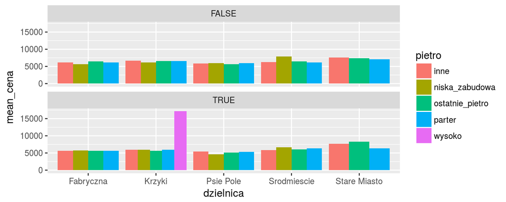

```r
ggplot(dat_srednia, aes(x = dzielnica, y = mean_cena, fill = pietro)) +
  geom_bar(stat = "identity", position = "dodge") +
  facet_wrap(~ duze, ncol = 1)
```

Dodajemy słupki błędów.

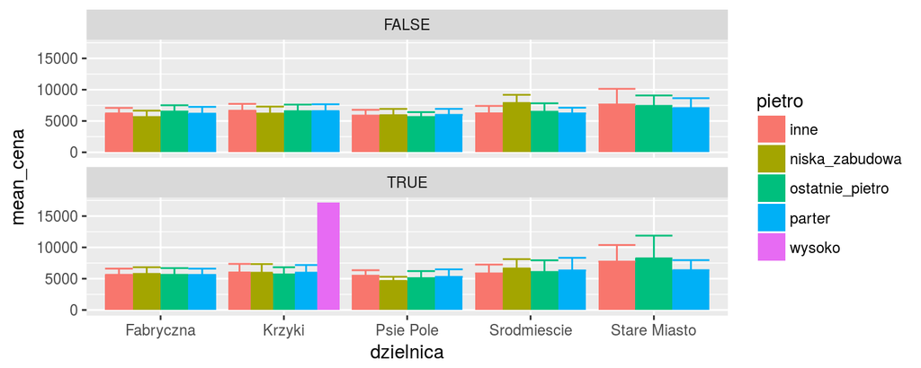

```r
ggplot(dat_srednia, aes(x = dzielnica, y = mean_cena, fill = pietro)) +
  geom_bar(stat = "identity", position = "dodge") +
  geom_errorbar(aes(ymax = mean_cena + sd_cena,
                    ymin = mean_cena, color = pietro), position = "dodge") +
  facet_wrap(~ duze, ncol = 1)
```

## Zadania

1. Oblicz medianę (*median*) i odchylenie standardowe mediany (*mad*) ceny metra kwadratowego w zależności od piętra i dzielnicy.
2. Stwórz wykres słupkowy przedstawiający mediany cen w zależności od dzielnicy.
3. Jako wypełnienie (*fill*) wybierz piętro.
4. Przedstaw odchylenie standardowe mediany w postaci słupków błędu.

## Wykres punktowy

## Wykres punktowy

- Każda obserwacja odpowiada jednemu punktowi na wykresie
- Wyznaczamy jaka zmienna ma odpowiadać każdej z osi

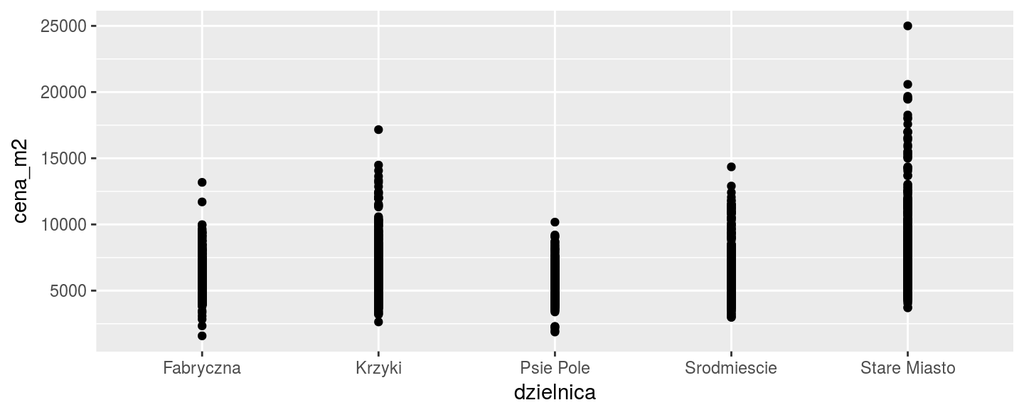

```r
ggplot(mieszkania, aes(x = dzielnica, y = cena_m2)) +
  geom_point()
```

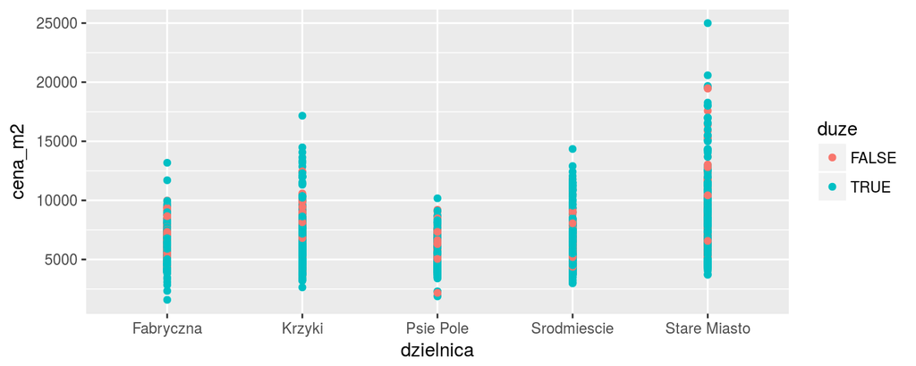

```r
ggplot(mieszkania, aes(x = dzielnica, y = cena_m2, col = duze)) +
  geom_point()
```

- Na poprzednim wykresie wszystko się zlewa
- Dodajemy opcję, żeby poszczególne punkty na siebie nie nachodziły

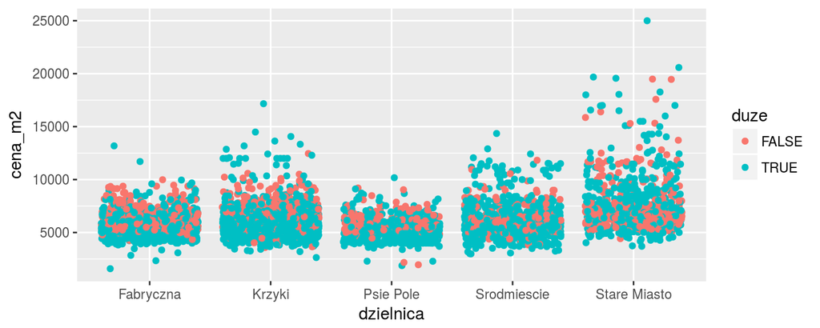

```r
ggplot(mieszkania, aes(x = dzielnica, y = cena_m2, col = duze)) +
  geom_point(position = "jitter")
```

- Ustawienie punktów jest tutaj losowe

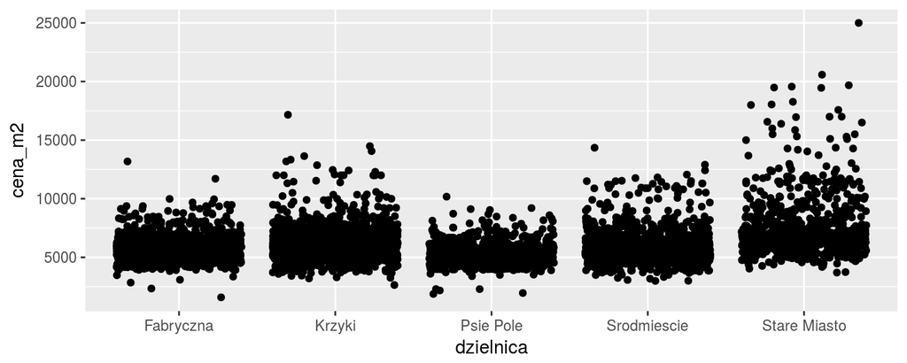

```r
set.seed(1410)
ggplot(mieszkania, aes(x = dzielnica, y = cena_m2)) +
  geom_point(position = "jitter")
```

## Zadania

1. Narysuj wykres zależności ceny mieszkania od jego powierzchni
2. Zaznacz dodatkowo kolorem dzielnicę
3. Narysuj wykres, który pokazuje zależność między powierzchnią mieszkania a liczbą pokojów
4. Pokaż zależność ceny \(m^2\) od zmiennej *pietro*
5. (opcjonalne) Dodaj do wykresu parametr *alpha = 0.2*. Co się zmieniło?

## Facets - podziały

Chcemy:

- zobaczyć jakie są ceny \(m^2\) w grupach zależnych od dzielnicy
- porównać średni metraż w zależności od piętra i liczby pokojów
- zestawić ze sobą wizulizacje w grupach wyznaczonych przez zmienne

Co jeśli chcemy zobaczyć rozkład punktów w grupach zależnych od liczby pokojów?

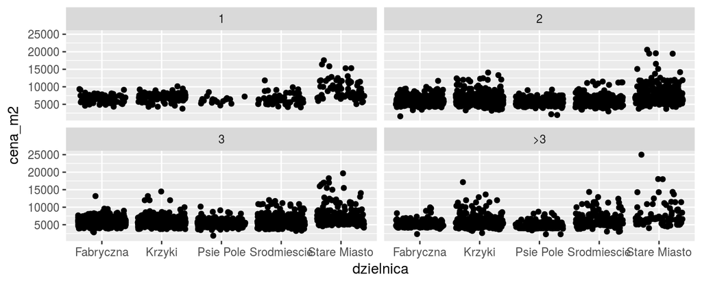

```r
ggplot(mieszkania, aes(x = dzielnica, y = cena_m2)) +
  geom_point(position = "jitter") +
  facet_wrap(~ pokoj)
```

Facets pozwalają wizualizować dane rozdzielone względem wartości określonego parametru.

Argument *labeller* pozwala na automatyczne nazywanie podwykresów.

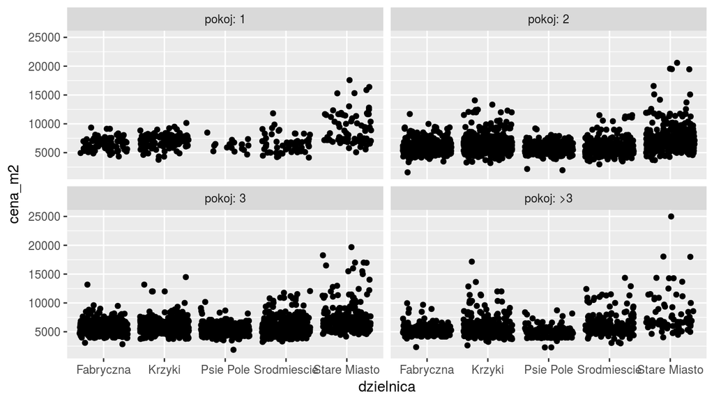

```r
ggplot(mieszkania, aes(x = dzielnica, y = cena_m2)) +
  geom_point(position = "jitter") +
  facet_wrap(~ pokoj, labeller = label_both)
```

Operator + pozwala na łącznie parametrów względem których dzielimy dane.

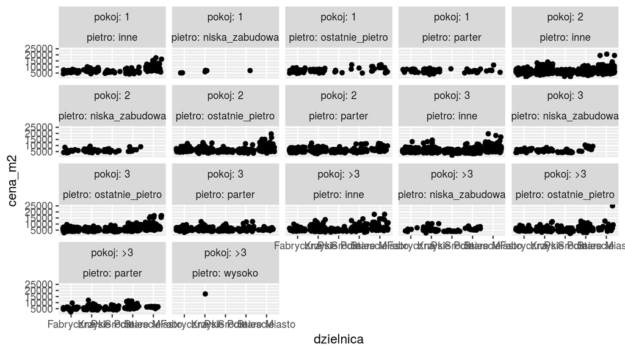

```r
ggplot(mieszkania, aes(x = dzielnica, y = cena_m2)) +
  geom_point(position = "jitter") +
  facet_wrap(~ pokoj + pietro, labeller = label_both)
```

facet_grid układa podwykresy w macierz, gdzie wartości dwóch parametrów definiują rzędy i kolumny.

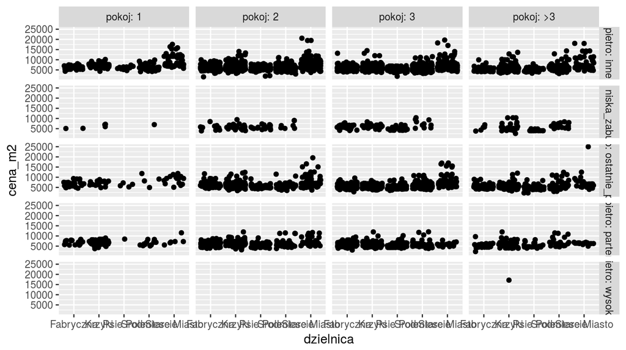

```r
ggplot(mieszkania, aes(x = dzielnica, y = cena_m2)) +
  geom_point(position = "jitter") +
  facet_grid(pietro ~ pokoj, labeller = label_both)
```

Facets mogą być wykorzystywane z dowolnym typem wykresów.

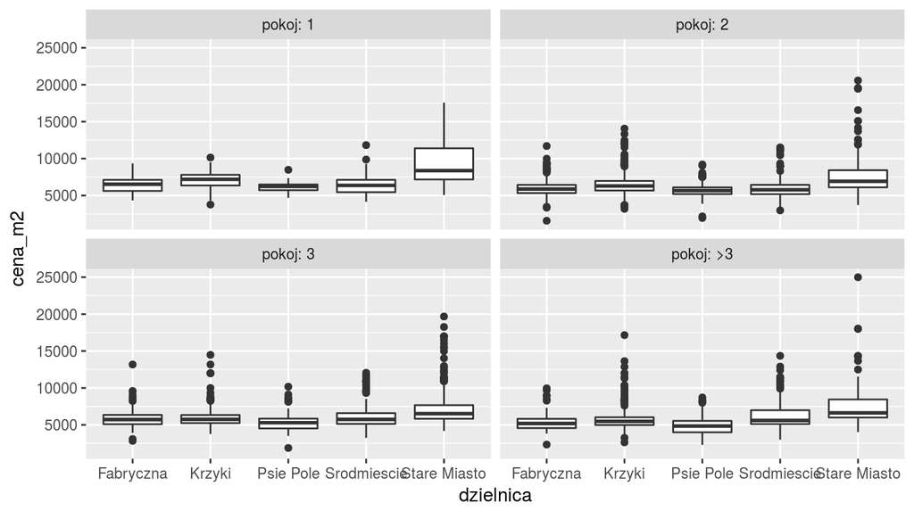

```r
ggplot(mieszkania, aes(x = dzielnica, y = cena_m2)) +
  geom_boxplot() +
  facet_wrap(~ pokoj, labeller = label_both)
```

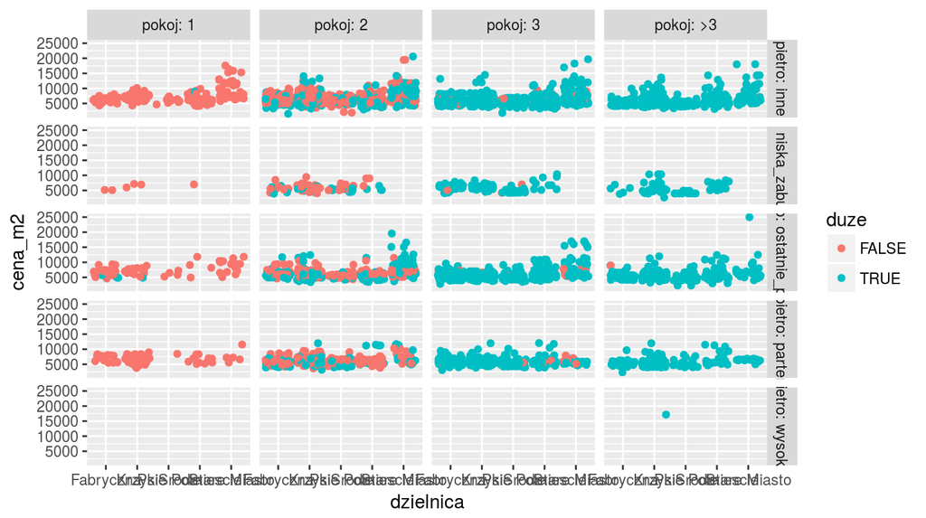

```r
ggplot(mieszkania, aes(x = dzielnica, y = cena_m2, color = duze)) +
  geom_point(position = "jitter") +
  facet_grid(pietro ~ pokoj, labeller = label_both)
```

## Zadania

1. Narysuj wykres punktowy przedstawiający zależność ceny \(m^2\) od liczby pokojów w podziale na dzielnice.
2. Narysuj wykres pudełkowy przedstawiający zależność ceny \(m^2\) od liczby pokojów w zależności od dzielnicy i piętra. Wykorzystaj facet_grid.

## Gęstość

## Gęstość

- Zorientowanie jakich wartości można się spodziewać
- Odporne na małe wahania

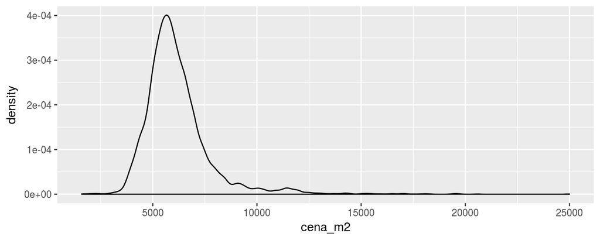

```r
ggplot(mieszkania, aes(x = cena_m2)) +
  geom_density()
```

- Podział ze względu na zmienną *pokoj*
- Mało czytelny ze względu na zbyt mocne kolory

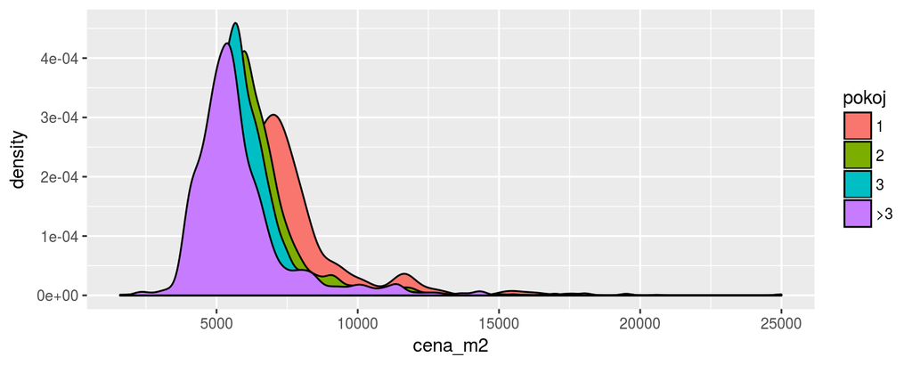

```r
ggplot(mieszkania, aes(x = cena_m2, fill = pokoj)) +
  geom_density()
```

- Dodanie przezroczystości

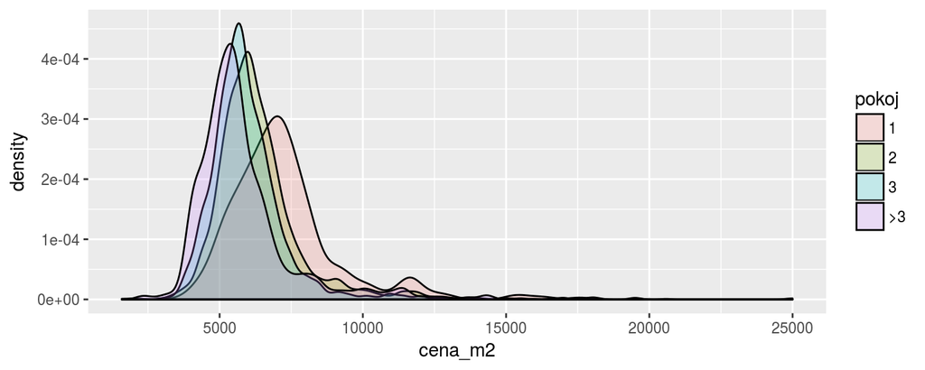

```r
ggplot(mieszkania, aes(x = cena_m2, fill = pokoj)) +
  geom_density(alpha = 0.2)
```

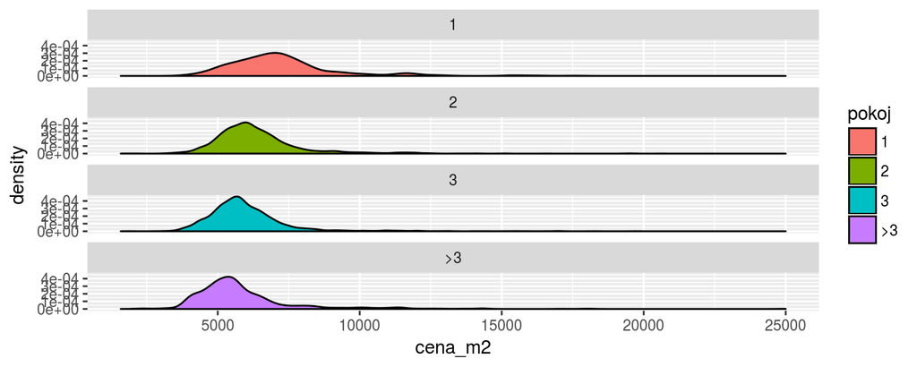

```r
ggplot(mieszkania, aes(x = cena_m2, fill = pokoj)) +
  geom_density() +
  facet_wrap(~pokoj, ncol=1)
```

- Parametr adjust odpowiada za ,,chropowatość"

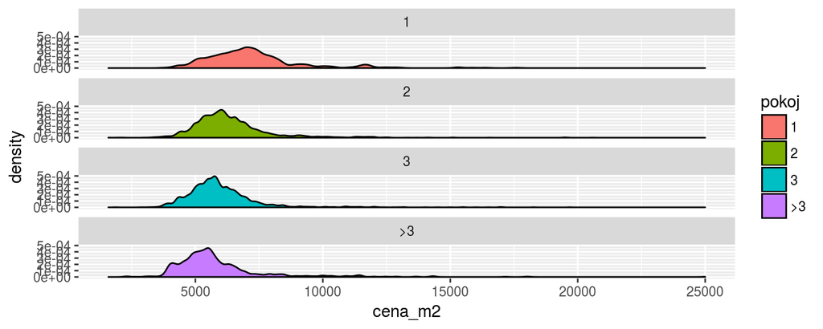

```r
ggplot(mieszkania, aes(x = cena_m2, fill = pokoj)) +
  geom_density(adjust = 0.5) +
  facet_wrap(~pokoj, ncol=1)
```

## Zadania

1. Zwizualizuj jak cena \(m^2\) zależy od dzielnicy. Jakie płyną stąd wnioski?
2. Zwizualizuj jak metraż zależy od liczby pokojów
3. Zobacz jak wyglądają powyższe wykresy w zależności od wartości parametru *adjust*
4. (opcjonalnie) Dla większej przejrzystości spróbuj ograniczyć możliwe wartości na osi x **xlim(min, max)**

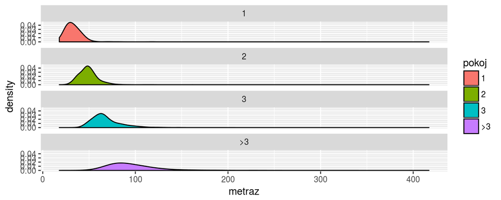

```r
ggplot(mieszkania, aes(x = metraz, fill = pokoj)) +
  geom_density(adjust = 2) +
  facet_wrap(~pokoj, ncol=1)
```

## Mapy

## Kartogram

```r
load("data/mapa_dzielnic.Rdata")

plot_data <- mieszkania %>%
  group_by(dzielnica) %>%
  summarise(cena_m2 = mean(cena_m2)) %>%
  inner_join(granice_dzielnic, by=c("dzielnica"="id"))
```

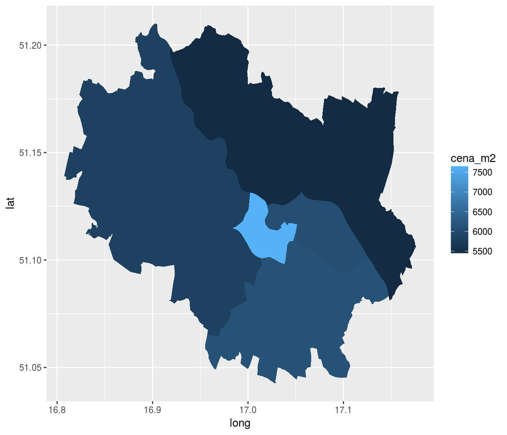

```r
ggplot(plot_data) +
  geom_polygon(aes(x=long, y=lat, group = dzielnica, fill = cena_m2))
```

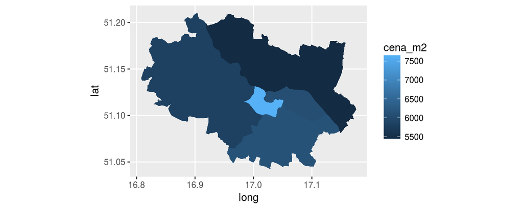

```r
ggplot(plot_data) +
  geom_polygon(aes(x=long, y=lat, group = dzielnica, fill = cena_m2)) +
  coord_map()
```

## Zadania

1. Narysuj kartogram z przeciętną wielkością mieszkania w poszczególnych dzielnicach
2. Narysuj kartogram pokazujący zróżnicowanie cen (odchylenie standardowe) w poszcególnych dzielnicach
3. Narysuj kartogram pokazujący jakie są najmnniejsze dostępne mieszkania w poszczególnych dzielnicach

## Dodatki

## Upiększenie wykresu

- Zamiast wymyślać koło…
- **ggthemes**
- scale_fill_

```r
library(ggthemes)
```

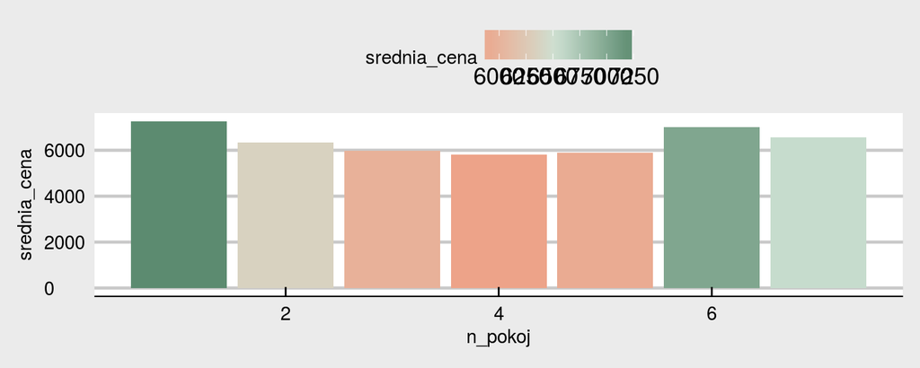

```r
ggplot(srednia_cena_pokoje, aes(x = n_pokoj, y = srednia_cena, fill = srednia_cena)) +
  geom_bar(stat = "identity") +
  scale_fill_gradient2_tableau(palette = "Light Red-Green") +
  theme_economist_white()
```

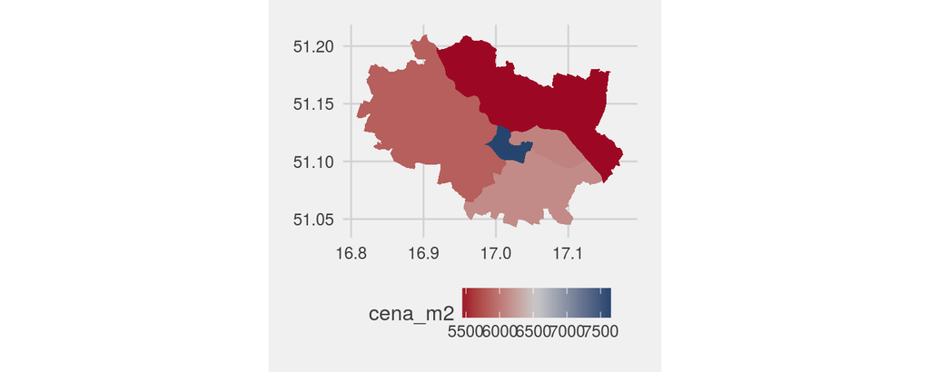

```r
ggplot(plot_data) +
  geom_polygon(aes(x=long, y=lat, group = dzielnica, fill = cena_m2)) +
  coord_map() +
  scale_fill_gradient2_tableau() + #skala kolorów z programu tableau
  theme_fivethirtyeight()  #wygląd wykresu wzorowany na fivethirtyeight
```

## Bee swarm

Wykresy punktowe mogą być nieczytelne, gdy punktów jest bardzo dużo.

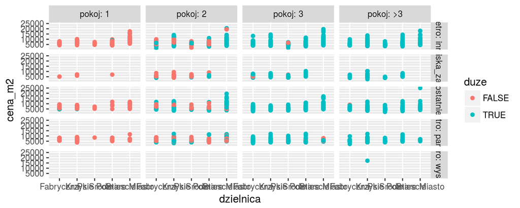

```r
ggplot(mieszkania, aes(x = dzielnica, y = cena_m2, color = duze)) +
  geom_point() +
  facet_grid(pietro ~ pokoj, labeller = label_both)
```

Losowe przesuwanie punktów nie jest zbyt przejrzyste.

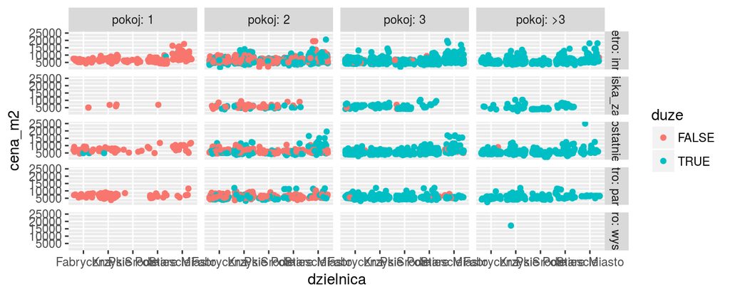

```r
ggplot(mieszkania, aes(x = dzielnica, y = cena_m2, color = duze)) +
  geom_point(position = "jitter") +
  facet_grid(pietro ~ pokoj, labeller = label_both)
```

Na ratunek przychodzą wykresy typu bee swarm, gdzie rozłożenie punktów jest pseudolosowe.

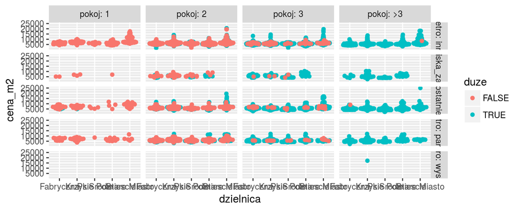

```r
library(ggbeeswarm)
ggplot(mieszkania, aes(x = dzielnica, y = cena_m2, color = duze)) +
  geom_quasirandom() +
  facet_grid(pietro ~ pokoj, labeller = label_both)
```

## Zadania

Porównaj efekty *geom_quasirandom(method = "smiley")* i *geom_quasirandom(method = "frowney")*.